# Expore and Summarize Physicochemical Property Data for Whie Wine Quality

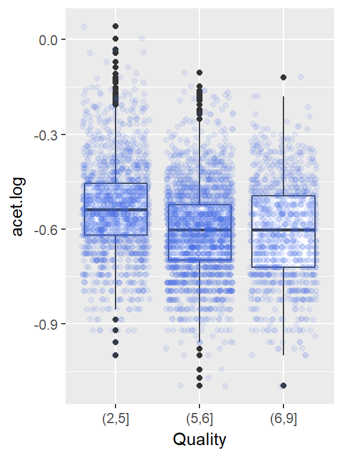

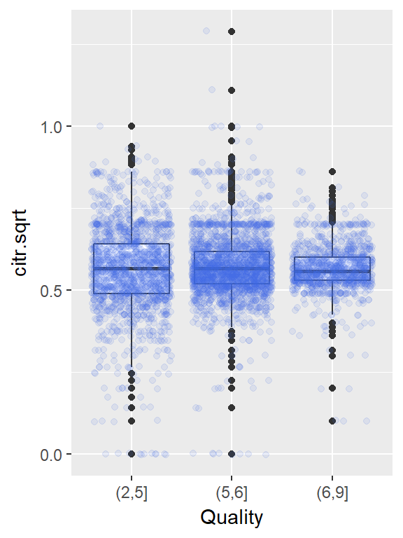

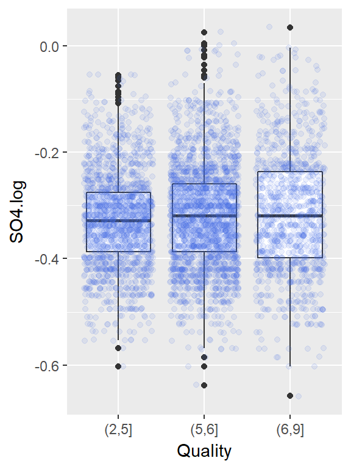

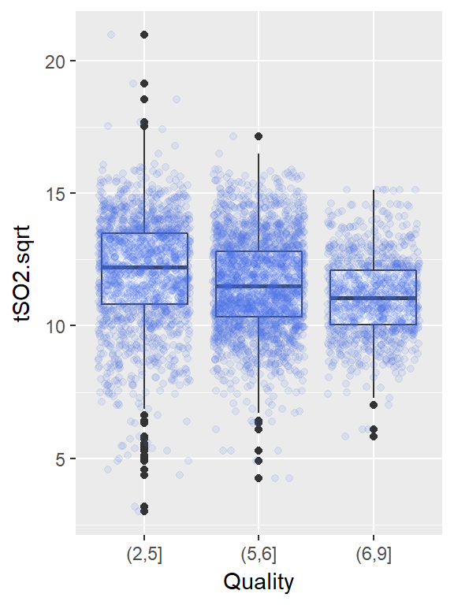

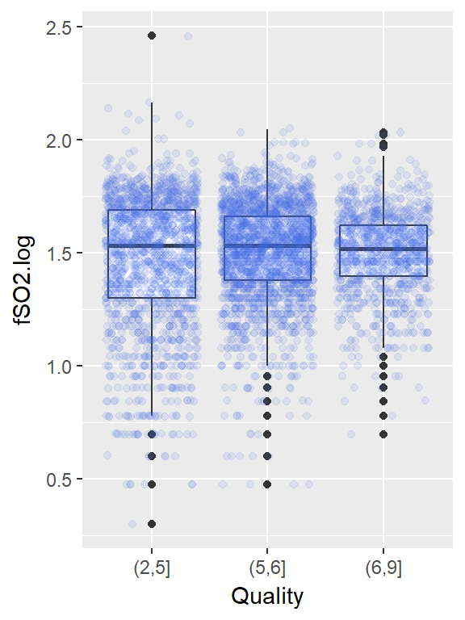

**Summary of findings from boxplots:**

- Alcohol, NaCl, density, and pH seem to have consistent trends from low to high quality wines. For the other properties, in contrast, the high quality wines share a similar distribution of the other level of quality.
- It is surprising to see some consistent trends of decreasing sugar with increasing quality from the boxplot although there is no correlation between sugar and quality (r = -0.065). This makes me wonder if linear relationship was hidden due to bimodality. And I will investigate sugar variable further in the later section.

Although boxplots show the general trends, I am not sure whether the differences are statistically significant or not. Thus, I will perform one-way ANOVA test on each variable by quality.con.

#### Are the differences statistically significant?

```
## [[1]]
## [1] "alco"
##
## [[2]]
##                  Df Sum Sq Mean Sq F value Pr(>F)
## ww$quality.con    2   1595   797.3   670.5 <2e-16 ***
## Residuals      4894   5820     1.2
## ---
## Signif. codes:  0 '***' 0.001 '**' 0.01 '*' 0.05 '.' 0.1 ' ' 1
##
## [[1]]
## [1] "suga.log"
##
## [[2]]
##                  Df Sum Sq Mean Sq F value   Pr(>F)
## ww$quality.con    2    7.1   3.552   22.39 2.08e-10 ***
## Residuals      4894  776.2   0.159
## ---
## Signif. codes:  0 '***' 0.001 '**' 0.01 '*' 0.05 '.' 0.1 ' ' 1
##
## [[1]]
## [1] "NaCl.log"
##
## [[2]]
##                  Df Sum Sq Mean Sq F value Pr(>F)
## ww$quality.con    2   8.48   4.241   223.7 <2e-16 ***
## Residuals      4894  92.80   0.019
## ---
## Signif. codes:  0 '***' 0.001 '**' 0.01 '*' 0.05 '.' 0.1 ' ' 1
##
## [[1]]
## [1] "dens"
##
## [[2]]
##                  Df  Sum Sq   Mean Sq F value Pr(>F)
## ww$quality.con    2 0.00489 0.0024429     324 <2e-16 ***
## Residuals      4894 0.03690 0.0000075
## ---
## Signif. codes:  0 '***' 0.001 '**' 0.01 '*' 0.05 '.' 0.1 ' ' 1
##
```

[output cut: 54 more lines]

```
##                  Df Sum Sq Mean Sq F value Pr(>F)
## ww$quality.con    2    559  279.69   85.56 <2e-16 ***
## Residuals      4894  15997    3.27
## ---
## Signif. codes:  0 '***' 0.001 '**' 0.01 '*' 0.05 '.' 0.1 ' ' 1
##
## [[1]]
## [1] "fSO2.log"
##
## [[2]]
##                  Df Sum Sq Mean Sq F value   Pr(>F)
## ww$quality.con    2   1.47  0.7365    13.1 2.11e-06 ***
## Residuals      4894 275.08  0.0562
## ---
## Signif. codes:  0 '***' 0.001 '**' 0.01 '*' 0.05 '.' 0.1 ' ' 1
```

Apperantly, the ANOVA test is not very helpful in this case because all variables significantly vary by quality.con.

### Density plots grouped by quality.lib

I will create density plots of all physicochemical properties grouped by quality.lib (<5, 5-7, >7) to find the trends of low-end and high-end cases. The advantage of density plot is the area under the curve is normalized for imbalanced class sizes. Agian, the purpose of drawing density plots all together is to look at the plots of all variables to determine which variables I need to do further investigation.

#### Is there any noticeable trend from low to high quality?

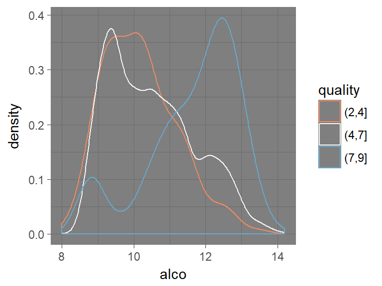

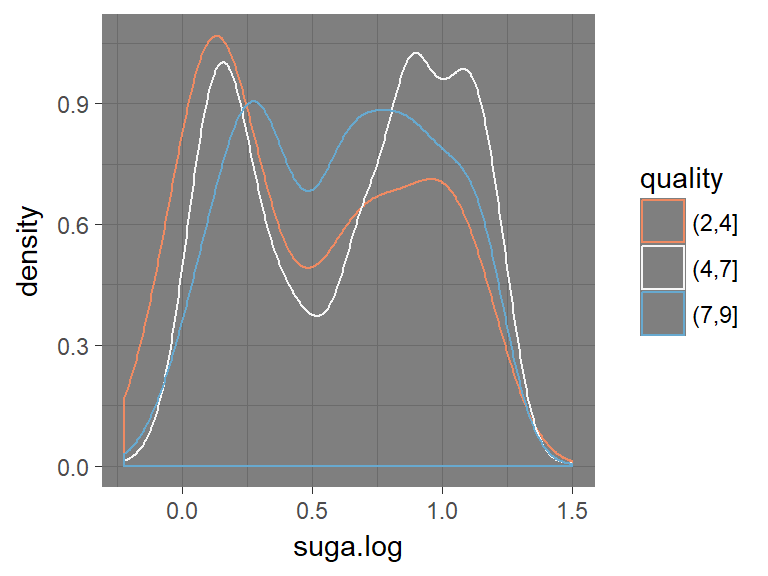

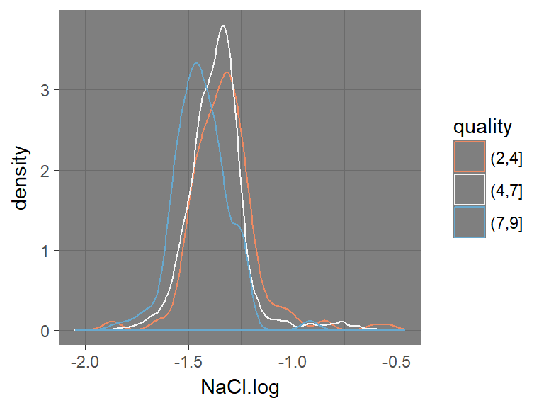

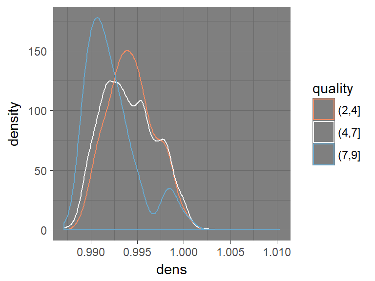

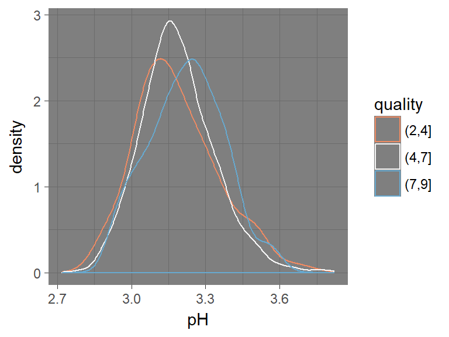

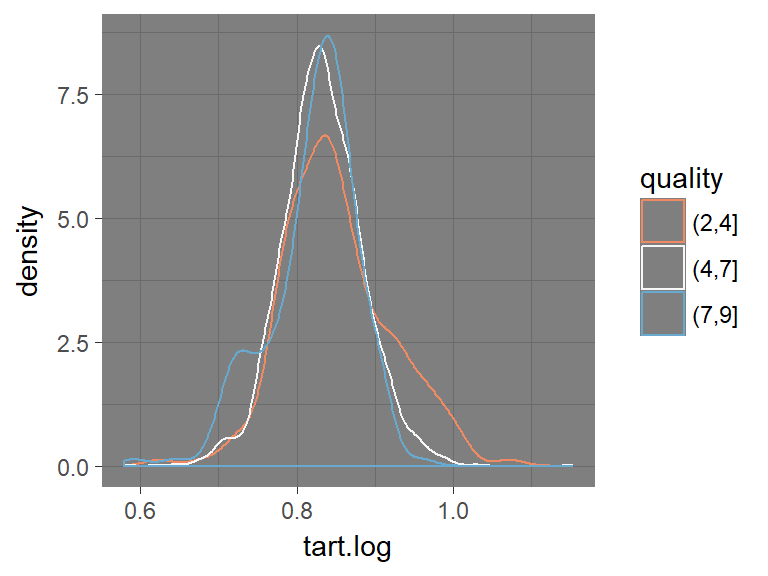

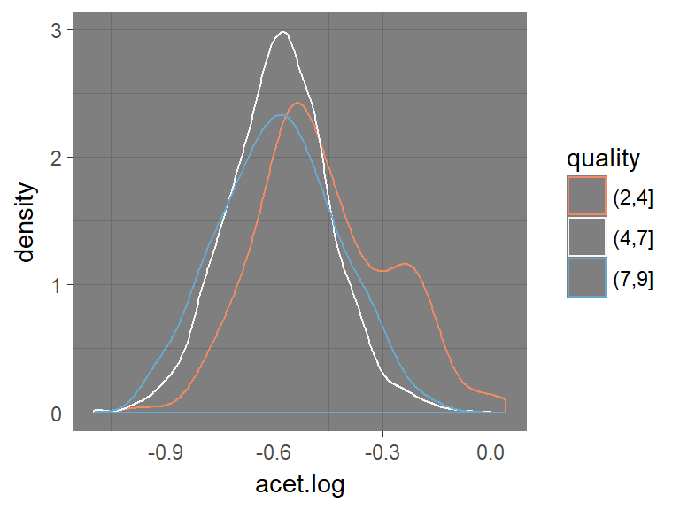

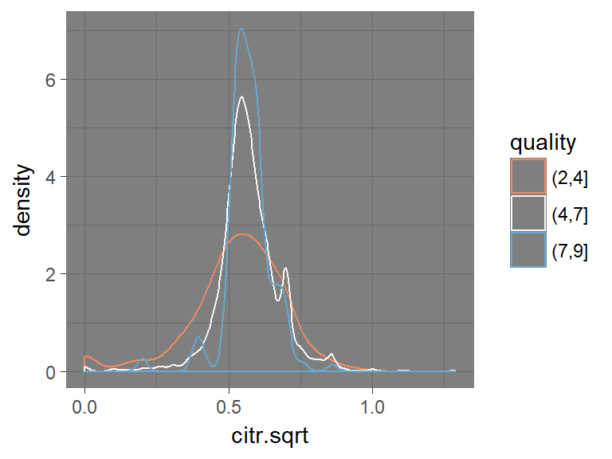

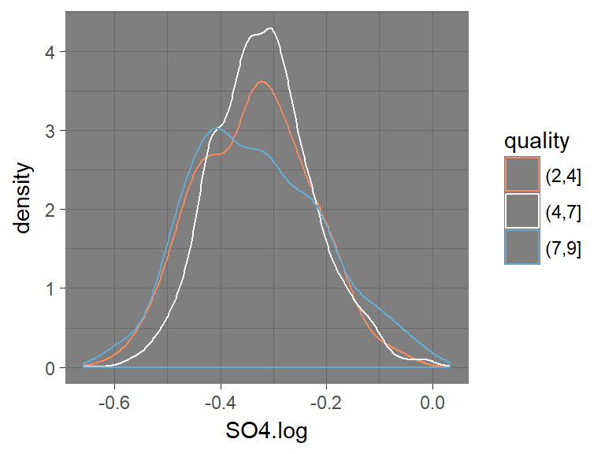

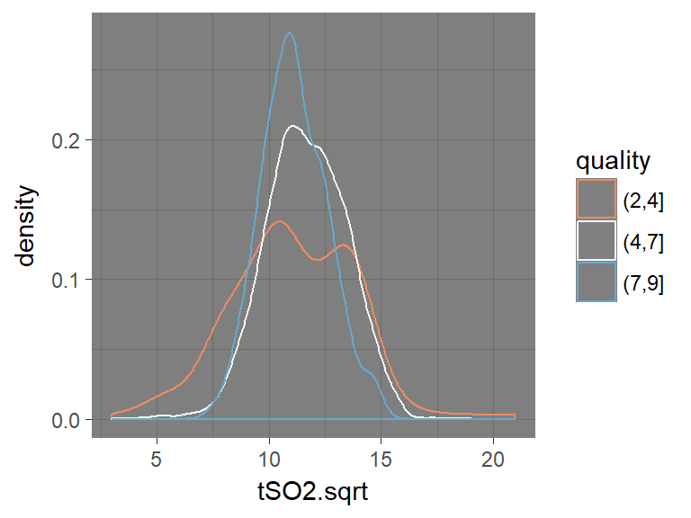

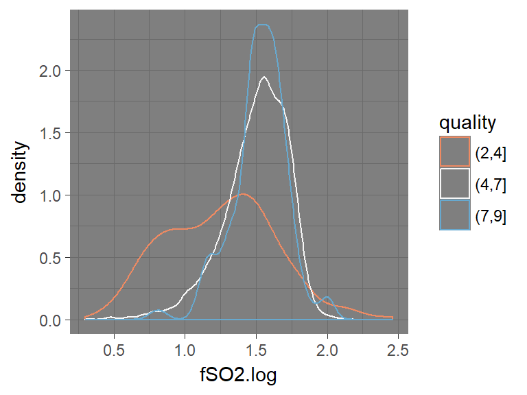

**Summary of findings from density plots:**

- The density plots of alcohol, NaCl, density, and pH are reconfirming that for these properties the distributions of very high quality differs from that of very low quality.
- SO4 of high quality wine has slightly different distribution from medium and low quality wine.
- acetic acid, total SO2 and free SO2 seem to have distinct trends of low quality wine compared to mediumn and high quality wine, which were not detected from boxplots. And I will investigate these variable further in the later section.

### Density plots and regression grouped by sugar.bucket

Due to bimodality of residual.sugar distribution, the regression and density plot could not detect clear trends. So, I will take look at the distributions separately by two groups (<2.5, >2.5).

#### What are the distributions of residual.sugar in the two separate groups? And what are the distribution of quality in the two groups?

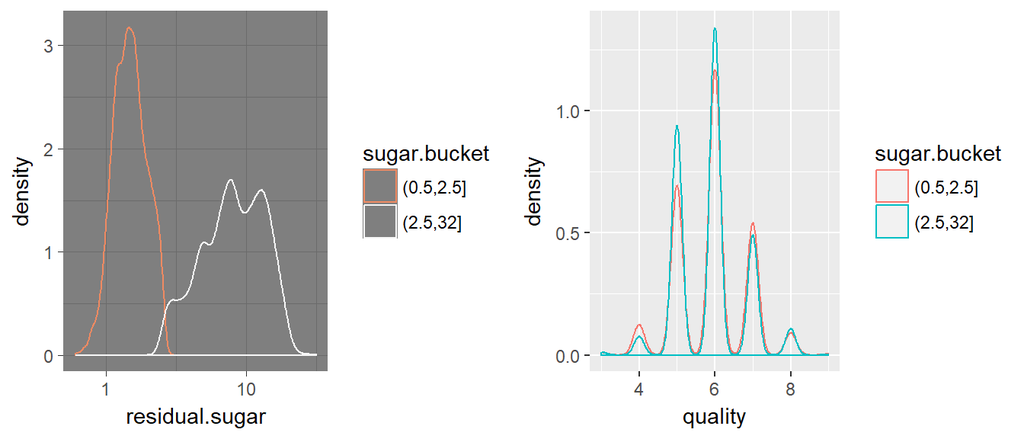

```
## [1] "residual.sugar"
```

```
## ww$sugar.bucket: (0.5,2.5]
##    Min. 1st Qu.  Median    Mean 3rd Qu.    Max.
##    0.60    1.20    1.50    1.53    1.80    2.50
## --------------------------------------------------------
## ww$sugar.bucket: (2.5,32]
##    Min. 1st Qu.  Median    Mean 3rd Qu.    Max.
##   2.600   5.500   8.200   9.037  12.200  31.600
```

```
## [1] "quality"
```

```
## ww$sugar.bucket: (0.5,2.5]
##    Min. 1st Qu.  Median    Mean 3rd Qu.    Max.
##   3.000   5.000   6.000   5.909   6.000   9.000
## --------------------------------------------------------
## ww$sugar.bucket: (2.5,32]
##    Min. 1st Qu.  Median    Mean 3rd Qu.    Max.
##   3.000   5.000   6.000   5.861   6.000   9.000
```

The distribution of each sub-group by sugar is close to normal with its own central. Low sugar group (<2.5) has a median of 1.5 while high sugar group (>2.5) had a median of 8.2. Despite the bimodality of residual.sugar distribution, the quality in both groups is distributed very similarly, with the quality median of 6.

#### Do correlations between sugar and quality differ in the two groups?

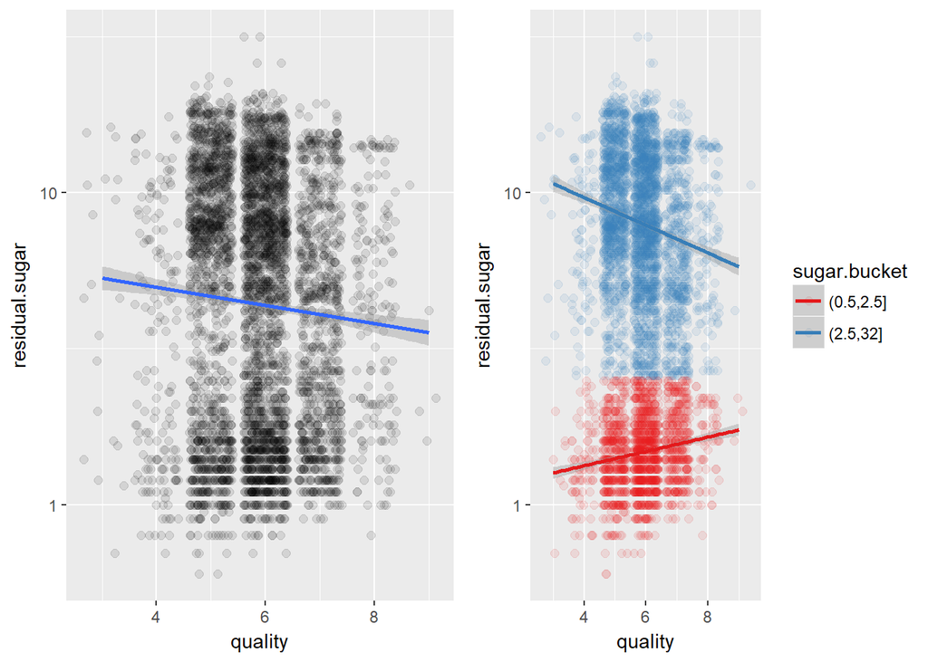

```
## [1] "(0.5,2.5]"
```

```
##
##  Pearson's product-moment correlation
##
## data:  residual.sugar and quality
## t = 7.2549, df = 1732, p-value = 6.038e-13
## alternative hypothesis: true correlation is not equal to 0
## 95 percent confidence interval:
##  0.1256761 0.2170529
## sample estimates:
##       cor
## 0.1717339
```

```
## [1] "(2.5,32]"
```

```
##
##  Pearson's product-moment correlation
##
## data:  residual.sugar and quality
## t = -8.9083, df = 3161, p-value < 2.2e-16
## alternative hypothesis: true correlation is not equal to 0
## 95 percent confidence interval:
##  -0.1903082 -0.1223092
## sample estimates:
##        cor
## -0.1564941
```

The correlation with quality is improved a little bit by separating into two groups. Low sugar group (0.5,2.5] is positively correlated with quality (r=0.172), while high sugar group (2.5,32] is negatively correlated with quality (r=-0.156).

### Relationship between freeSO2 vs. quality

The density plot of freeSO2 showed an interesting trend although linear regression and boxplot did not show any promising trends. Low quality wines are relatively more distributed to high-end as well as low-end freeSO2 while medium and high quality wines remain at the middle level of freeSO2. I wonder if too high or too low amounts of freeSO2 are related to low quality of wine.

#### What are the distributions of quality in the bucket by freeSO2?

```
## [[1]]
## [[1]][[1]]
## [1] "% of each group"
##
## [[1]][[2]]
## col
##      (1,5]     (5,50]   (50,120]  (120,290]
##  0.9597713 81.3150909 17.5821932  0.1429447
##
##
## [[2]]
```

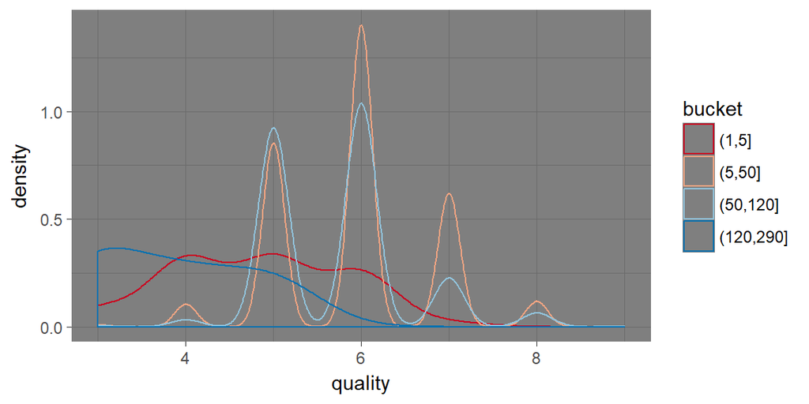

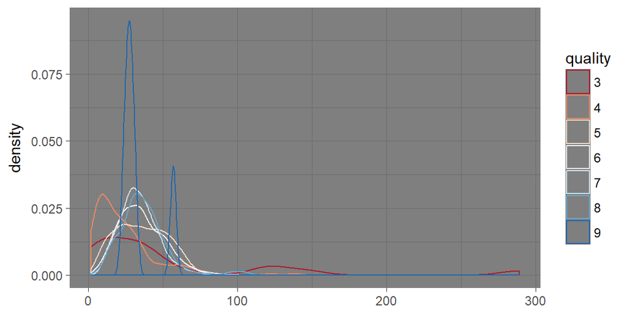

```
##
## [[4]]
## [1] "quality"
##
## [[5]]
## bucket: (1,5]
##    Min. 1st Qu.  Median    Mean 3rd Qu.    Max.
##   3.000   4.000   5.000   4.809   6.000   7.000
## --------------------------------------------------------
## bucket: (5,50]
##    Min. 1st Qu.  Median    Mean 3rd Qu.    Max.
##   3.000   5.000   6.000   5.928   6.000   9.000
## --------------------------------------------------------
## bucket: (50,120]
##    Min. 1st Qu.  Median    Mean 3rd Qu.    Max.
##    3.00    5.00    6.00    5.72    6.00    9.00
## --------------------------------------------------------
## bucket: (120,290]
##    Min. 1st Qu.  Median    Mean 3rd Qu.    Max.
##   3.000   3.000   4.000   3.857   4.500   5.000
```

According to [data info notes](https://s3.amazonaws.com/udacity-hosted-downloads/ud651/wineQualityInfo.txt), free SO2 over 50 mg/L becomes evident in the nose and taste of wine, but the measurement of free SO2 alone is not necessary to determine wine quality.

Majority of wines (82%) have free SO2 below 50 mg/L. The density plot shows that the quality of wine with below and above 50 mg/L of free SO2 are distributed similarly. However, the quality of extreme case (1% of the wine samples) where free SO2 are lower than 5 mg/L (1% of the sample size) or higher than 120 mg/L (0.1% of the sample size) is shown to be low. So, if white wine has too little or too much free SO2, the quality unlikely would be higher than 6. This suggest that free SO2 is required at a certain level (20-50 mg/L) to compromise between preservation purpose (antioxidant) and good smell, but there is no linear relationship between free SO2 and quality.

### Relationship between totalSO2 vs. quality

Total SO2 has a similar trend but a lesser extent like freeSO2 has.

#### What are the distributions of quality in the bucket by totalSO2?

```
## [[1]]
## [[1]][[1]]
## [1] "% of each group"
##
## [[1]][[2]]
## col
##     (8,30]    (30,50]   (50,250]  (250,440]
##  0.3879926  0.6126200 98.5092914  0.4900960
##
##
## [[2]]
```

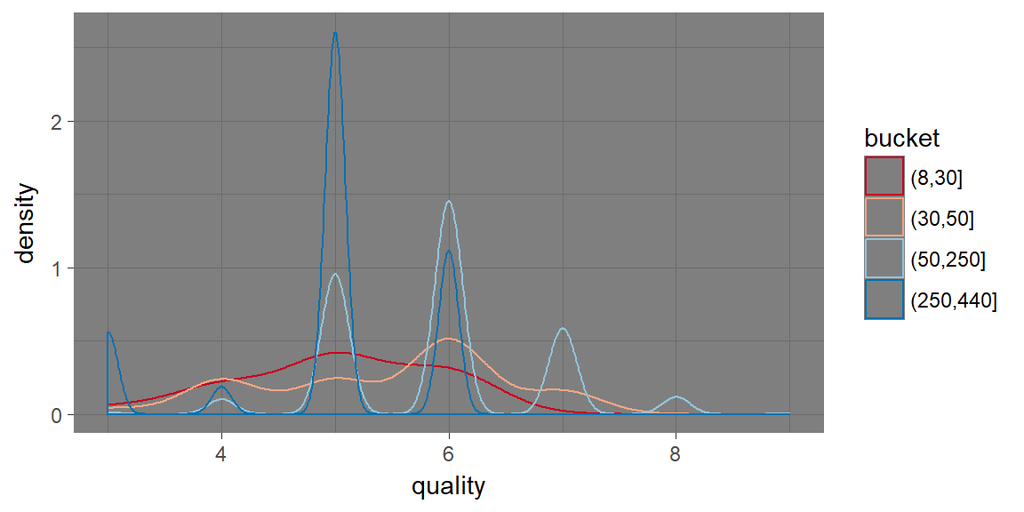

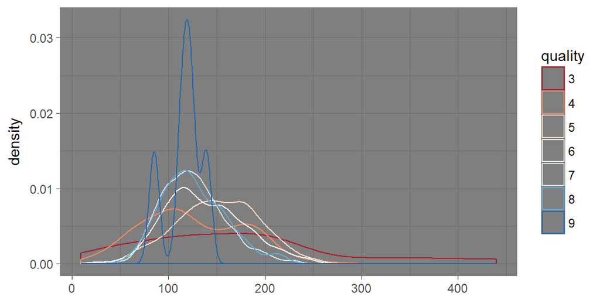

```
##
## [[4]]
## [1] "quality"
##
## [[5]]
## bucket: (8,30]
##    Min. 1st Qu.  Median    Mean 3rd Qu.    Max.
##     3.0     4.5     5.0     5.0     6.0     6.0
## --------------------------------------------------------
## bucket: (30,50]
##    Min. 1st Qu.  Median    Mean 3rd Qu.    Max.
##   3.000   5.000   6.000   5.433   6.000   7.000
## --------------------------------------------------------
## bucket: (50,250]
##    Min. 1st Qu.  Median    Mean 3rd Qu.    Max.
##   3.000   5.000   6.000   5.889   6.000   9.000
## --------------------------------------------------------
## bucket: (250,440]
##    Min. 1st Qu.  Median    Mean 3rd Qu.    Max.
##   3.000   5.000   5.000   4.958   5.250   6.000
```

Similarly, the quality of extreme case (0.9% of the wine samples) where total SO2 are lower than 30 mg/L or higher than 250 mg/L is shown to be low. So, if white wine has too little or too much total SO2, the quality unlikely would be higher than 6.

### Relationship between acetic acid vs. quality

The distribution of acetic acid by quality also suggests the possibility of that high-end values are an indicator of low quality wine.

#### What are the distributions of quality in the bucket by acetic acid?

```
## [[1]]
## [[1]][[1]]
## [1] "% of each group"
##
## [[1]][[2]]
## col
##    (0,0.8]  (0.8,1.1]
## 99.8570553  0.1429447
##
##
## [[2]]
```

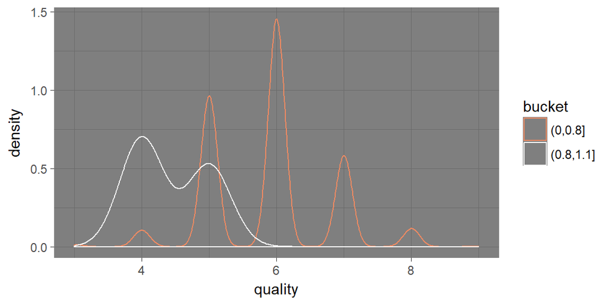

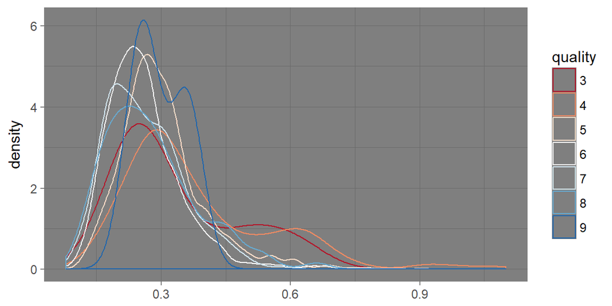

```
##
## [[4]]
## [1] "quality"
##
## [[5]]
## bucket: (0,0.8]
##    Min. 1st Qu.  Median    Mean 3rd Qu.    Max.
##    3.00    5.00    6.00    5.88    6.00    9.00
## --------------------------------------------------------
## bucket: (0.8,1.1]
##    Min. 1st Qu.  Median    Mean 3rd Qu.    Max.
##   4.000   4.000   4.000   4.429   5.000   5.000
```

It is very rare (0.1% of the sample size) that the wine would have acetic acid exceeding 0.8 g/L but if white wine has too much acetic acid, the quality unlikely would be higher than 5.

### Relationship between citric acid vs. quality

Although the median of citric acid is 0.32, there is unusual high count (4% of sample size) at 0.49 g/L and there is zero value for about 0.4% of sample.

#### What are the distributions of quality when citric acid is at 0.49 or 0?

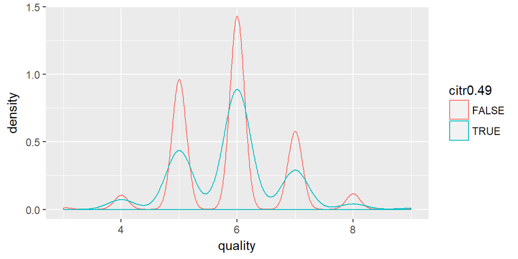

```
## [1] "citr0.49"
```

```
## ww$citric.acid == 0.49: FALSE
##    Min. 1st Qu.  Median    Mean 3rd Qu.    Max.
##   3.000   5.000   6.000   5.877   6.000   9.000
## --------------------------------------------------------
## ww$citric.acid == 0.49: TRUE
##    Min. 1st Qu.  Median    Mean 3rd Qu.    Max.
##   4.000   5.000   6.000   5.893   6.000   9.000
```

```
## [1] "citr0"
```

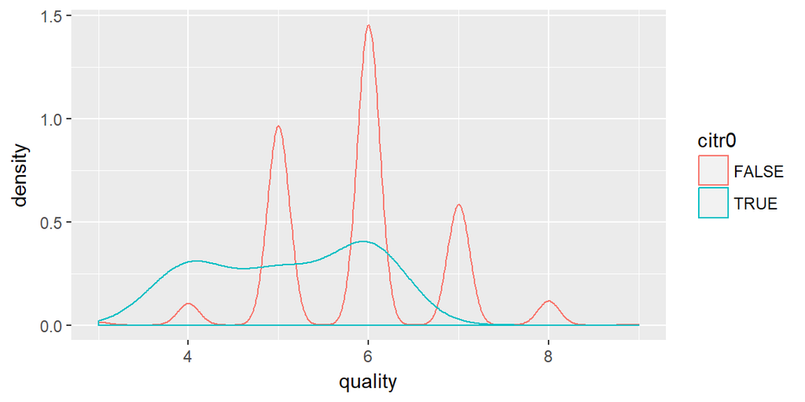

```
## ww$citric.acid == 0: FALSE
##    Min. 1st Qu.  Median    Mean 3rd Qu.    Max.
##   3.000   5.000   6.000   5.881   6.000   9.000
## --------------------------------------------------------
## ww$citric.acid == 0: TRUE
##    Min. 1st Qu.  Median    Mean 3rd Qu.    Max.
##   4.000   4.000   5.000   5.105   6.000   6.000
```

The quality distribution of the group with citric acid of 0.49 seems similar to the distribution by remaining samples, while the wines with zero citric acid are relatively lower in quality, and they unlikely would have quality higher than 6.

## 2.2.2 Bivariate Analysis

### Talk about some of the relationships you observed in this part of the investigation. How did the feature(s) of interest vary with other features in the dataset?

The scatterplot matrix, boxplots and density plots grouped by quality.con and qality.lib, consistently showed relationship of quality with alcohol, density and NaCl, and to a lesser extent with pH, acetic acid, and total SO2. The highest correlation r values with quality were alcohol and density, but were not that strong: 0.436 and -0.307, respectively. And none of single variable alone can explain the variance in quality score more than 19%. I wonder if the combination of two or more variables can make better prediction model for quality.

It was surprising to see some consistent trends of decreasing sugar with increasing quality from the boxplot although there was no correlation between sugar and quality (r = -0.065). Due to bimodality, some relationship could be hidden. The data of each modal behaved differently with quality. In low sugar group (<2.5 g/L), sugar was positively correlated with quality (r=0.172), while in high sugar group (>2.5 g/L), sugar was negatively correlated with quality (r=-0.156).

freeSO2, totalSO2, and acetic acid showed that the extremely high or/and low values or even zero values of these variables were associated with low quality wine, though the extreme cases were very rare like about 0.1 to 1 %.

### Did you observe any interesting relationships between the other features (not the main feature(s) of interest)?

Strong correlations were detected among density, alcohol, total SO2, sugar, and NaCl. This indicated that these variables might be dependent on each other for some degree. The density of wine depends on content of alcohol, sugar, salts etc. Because alcohol is lighter than water (1kg/L), the more alcohol, the lower density can be achieved. And since solute such as sugar, NaCl, and SO2 contributes to adding density of solution, the more solute, the higher density can be achieved. As mentioned at the univariate analysis, during the fermentation process, sugar is taken up by yeast to produce alcohol. In general, the more alcohol content in wine, the less sugar remains. These correlations were observed either strongly or weakly.

### What was the strongest relationship you found?

The correlations between density and alcohol and between density and sugar were the strongest in white wine dataset with r value of -0.78 and 0.756, respectively. This information can be helpful for guiding wine choice based on taste preference such as sweat or dry and heavy- or light-bodied, yet weakly predicting wine based on quality.

Among physicochemical properties, a single variable that had the strongest correlation with quality was alcohol. Wine with higher content of alcohol tended to be high in quality. Nonetheless, alcohol was explaining only 19% of the variance in quality, thus alcohol cannot be an only parameter for quality prediction model.

## 2.3.1 Multivariate Plots Section

### PCA (Principal component analysis)

One way to deal with multivariate dataset is to reduce dimensionality by using PCA. For the first attempt, I will use all physicochemical properties from ww_trans dataframe. PCA might be very sensitive to different units and differences in variability among the variables. So, I will run PCA with scale which standardizing the variables to have 0 mean and 1 std.

#### What are the stdev and variance of each component, and variance?

```
## Importance of components:
##                           PC1    PC2    PC3     PC4     PC5     PC6
## Standard deviation     1.8159 1.2686 1.1255 1.03269 0.98283 0.90679
## Proportion of Variance 0.2998 0.1463 0.1152 0.09695 0.08781 0.07475
## Cumulative Proportion  0.2998 0.4461 0.5612 0.65817 0.74599 0.82074
##                            PC7     PC8    PC9    PC10    PC11
## Standard deviation     0.83135 0.75450 0.6293 0.52667 0.19496
## Proportion of Variance 0.06283 0.05175 0.0360 0.02522 0.00346
## Cumulative Proportion  0.88357 0.93532 0.9713 0.99654 1.00000
```

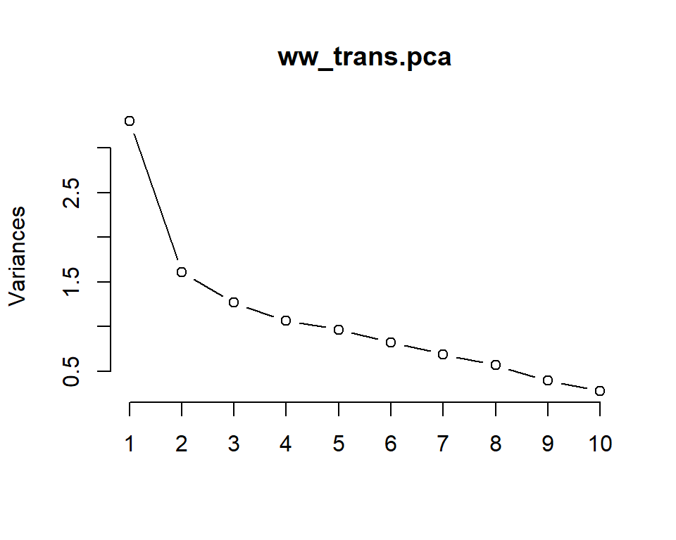

[The Kaiser criterion](http://www.uta.edu/faculty/sawasthi/Statistics/stfacan.html) suggested that we can retain only factors with eigenvalues greater than 1. That means I can keep PC1 through PC4. But the obvious change in slope occurs between 2 and 3, which is the elbow of the scree plot. I can focus on PC1 and PC2.

#### What are the correlations of variables with PC1 and PC2?

```
##                   PC1         PC2
## alco       0.43512266  0.02159992
## suga.log  -0.39626715 -0.02211873
## NaCl.log  -0.29465058 -0.03245198
## dens      -0.50359238  0.01015613
## pH         0.11509049 -0.57576969
## tart.log  -0.15916575  0.59223514
## acet.log  -0.01202803 -0.08435591
## citr.sqrt -0.12727418  0.37462691
## SO4.log   -0.06586485 -0.21391265
## tSO2.sqrt -0.40959900 -0.22303795
## fSO2.log  -0.29357094 -0.26957177
```

#### Visualize variable loadings

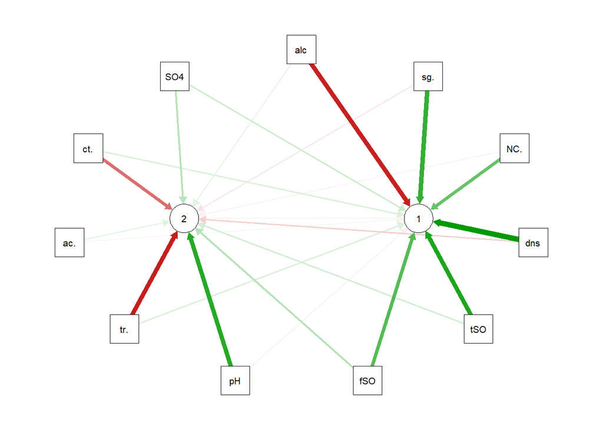

#### Visualize PCA

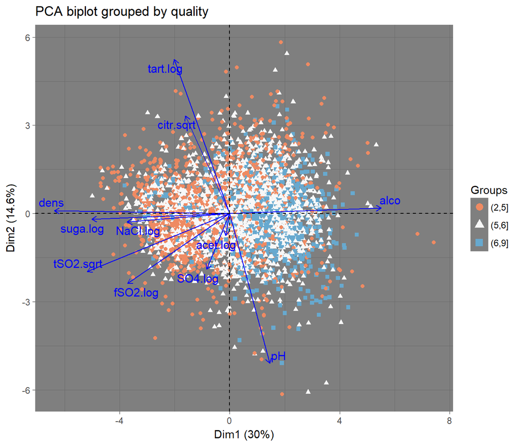

As I expect, there is no distinct grouping by quality.con. The classes of quality are highly overlapping. However, there is a general trend of low to high quality from left top to right bottom, where most low quality wines are on the left side (Dim1<0) while most high quality wines are on the right side (Dim1>0). Thus, the quality seems positively related to Dim1 or PC1 which is highly influence by alcohol, density, sugar, NaCl, and total SO2.

#### What is the correlation between PC1 and quality?

```
##
##  Pearson's product-moment correlation
##
## data:  ww_trans.pca$x[, 1] and ww$quality
## t = 20.603, df = 4895, p-value < 2.2e-16
## alternative hypothesis: true correlation is not equal to 0
## 95 percent confidence interval:
##  0.2565039 0.3080556
## sample estimates:
##       cor
## 0.2824837
```

The correlation r value between PC1 and quality is 0.282, which is not better than correlation between quality and alcohol alone (0.436). So, using all variables into PCA does not improve in explaining quality.

#### How about 3D-plot using PC1, PC2, and PC3?

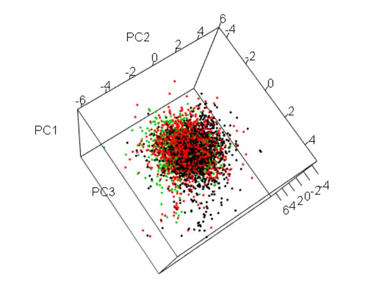

3D PCA plot

The 3D-plot of PCA does not show any better separation of the classes.

#### What about selecting only variables that are often shown to be related each other? Would this improve in explaining quality?

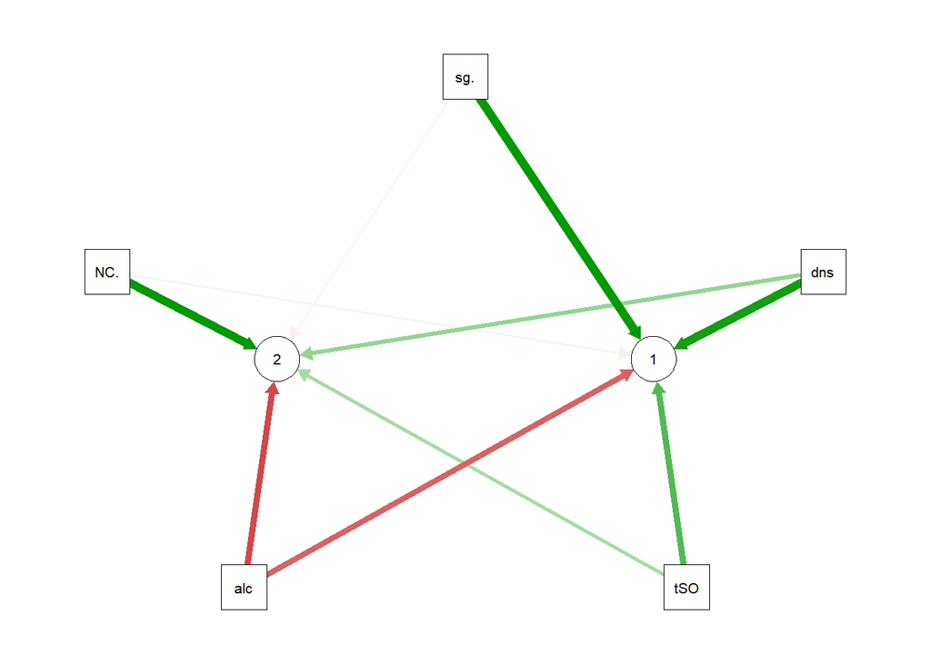

```
## Importance of components:
##                           PC1    PC2    PC3     PC4    PC5
## Standard deviation     1.7178 0.9621 0.7835 0.66298 0.2646
## Proportion of Variance 0.5902 0.1851 0.1228 0.08791 0.0140
## Cumulative Proportion  0.5902 0.7753 0.8981 0.98600 1.0000
```

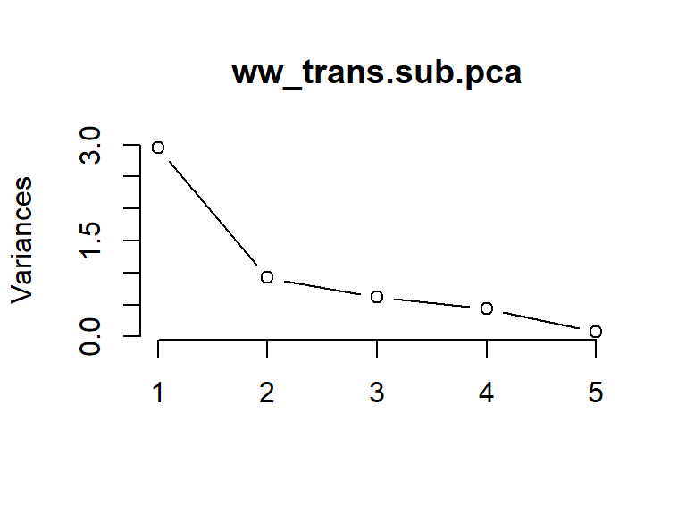

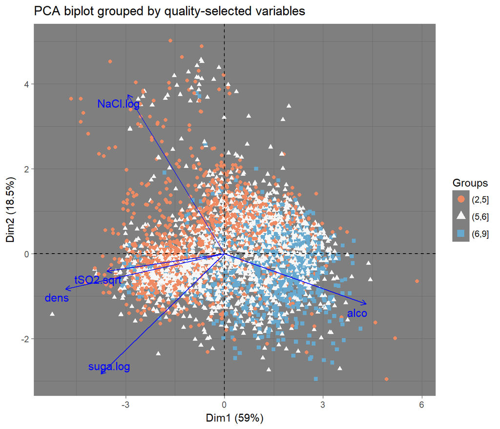

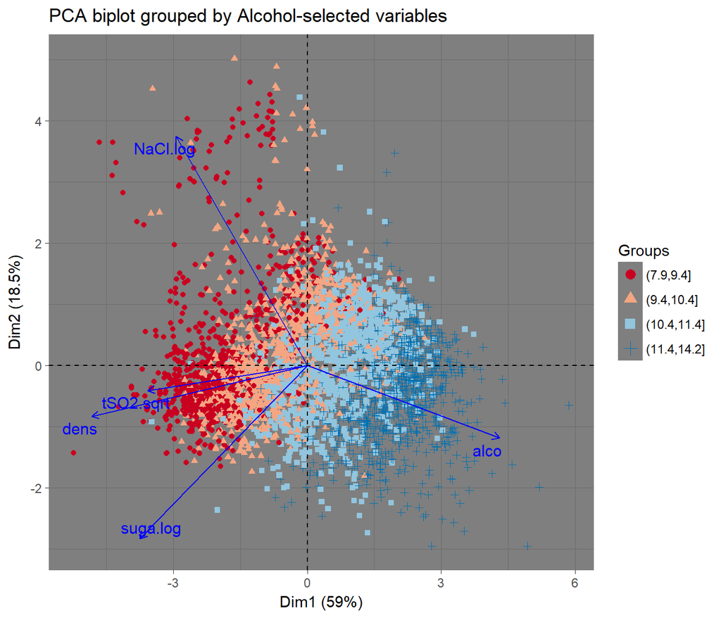

#### What is the correlation between PC1_selected and quality?

```
##
##  Pearson's product-moment correlation
##
## data:  ww_trans.sub.pca$x[, 1] and ww$quality
## t = 24.48, df = 4895, p-value < 2.2e-16
## alternative hypothesis: true correlation is not equal to 0
## 95 percent confidence interval:
##  0.3050709 0.3549838
## sample estimates:
##       cor
## 0.3302582
```

It helps little bit. The correlation r value is 0.330 but the individual points become spread out compared to all variables PCA.

#### How about 3D-plot using PC1, PC2, and PC3?

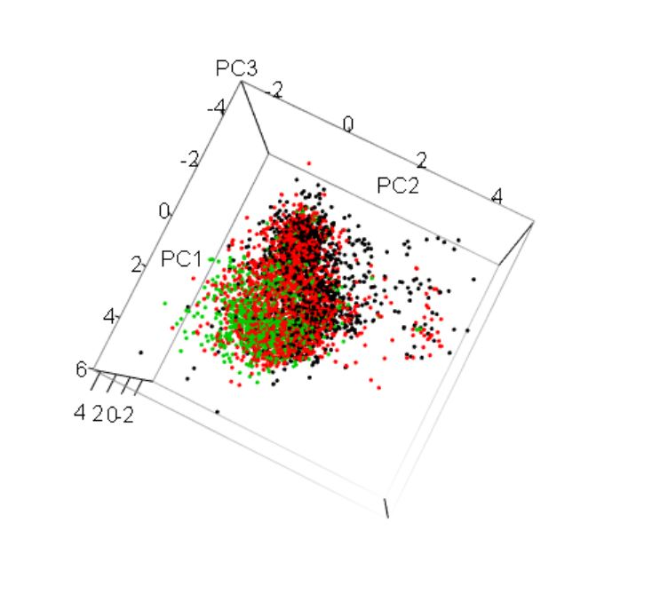

3D PCA plot with subset

Again, the separation by classes is not very good.

### Building the Linear Model

#### Can the combination of PCA scores explain quality?

```
##
## Calls:
## m1: lm(formula = ww$quality ~ PC1)
## m2: lm(formula = ww$quality ~ PC1 + PC2)
## m3: lm(formula = ww$quality ~ PC1 + PC2 + PC3)
## m4: lm(formula = ww$quality ~ PC1 + PC2 + PC3 + PC4)
## m5: lm(formula = ww$quality ~ PC1 + PC2 + PC3 + PC4 + PC5)
## m6: lm(formula = ww$quality ~ PC1 + PC2 + PC3 + PC4 + PC5 + PC6)
## m7: lm(formula = ww$quality ~ PC1 + PC2 + PC3 + PC4 + PC5 + PC6 +
##     PC7)
## m8: lm(formula = ww$quality ~ PC1 + PC2 + PC3 + PC4 + PC5 + PC6 +
##     PC7 + PC8)
## m9: lm(formula = ww$quality ~ PC1 + PC2 + PC3 + PC4 + PC5 + PC6 +
##     PC7 + PC8 + PC9)
## m10: lm(formula = ww$quality ~ PC1 + PC2 + PC3 + PC4 + PC5 + PC6 +
##     PC7 + PC8 + PC9 + PC10)
## m11: lm(formula = ww$quality ~ PC1 + PC2 + PC3 + PC4 + PC5 + PC6 +
##     PC7 + PC8 + PC9 + PC10 + PC11)
##
## ===========================================================================================================================================
##                      m1         m2         m3         m4         m5         m6         m7         m8         m9         m10        m11
## -------------------------------------------------------------------------------------------------------------------------------------------
##   (Intercept)      5.878***   5.878***   5.878***   5.878***   5.878***   5.878***   5.878***   5.878***   5.878***   5.878***   5.878***
##                   (0.012)    (0.012)    (0.012)    (0.011)    (0.011)    (0.011)    (0.011)    (0.011)    (0.011)    (0.011)    (0.011)
##   PC1              0.138***   0.138***   0.138***   0.138***   0.138***   0.138***   0.138***   0.138***   0.138***   0.138***   0.138***
##                   (0.007)    (0.007)    (0.006)    (0.006)    (0.006)    (0.006)    (0.006)    (0.006)    (0.006)    (0.006)    (0.006)
##   PC2                        -0.043***  -0.043***  -0.043***  -0.043***  -0.043***  -0.043***  -0.043***  -0.043***  -0.043***  -0.043***
##                              (0.010)    (0.009)    (0.009)    (0.009)    (0.009)    (0.009)    (0.009)    (0.008)    (0.008)    (0.008)
##   PC3                                   -0.178***  -0.178***  -0.178***  -0.178***  -0.178***  -0.178***  -0.178***  -0.178***  -0.178***
##                                         (0.010)    (0.010)    (0.010)    (0.010)    (0.010)    (0.010)    (0.009)    (0.009)    (0.009)
##   PC4                                               0.253***   0.253***   0.253***   0.253***   0.253***   0.253***   0.253***   0.253***
##                                                    (0.011)    (0.011)    (0.011)    (0.011)    (0.011)    (0.010)    (0.010)    (0.010)
##   PC5                                                          0.051***   0.051***   0.051***   0.051***   0.051***   0.051***   0.051***
##                                                               (0.011)    (0.011)    (0.011)    (0.011)    (0.011)    (0.011)    (0.011)
##   PC6                                                                    -0.074***  -0.074***  -0.074***  -0.074***  -0.074***  -0.074***
##                                                                          (0.012)    (0.012)    (0.012)    (0.012)    (0.012)    (0.012)
##   PC7                                                                                0.031*     0.031*     0.031*     0.031*     0.031*
##                                                                                     (0.013)    (0.013)    (0.013)    (0.013)    (0.013)
```

[output cut: 20 more lines]

Unfortunately, the r-squared value of this linear model is 0.302, meaning this model can explain only 30% of variance in quality.

#### Can the combination of transformed variables explain quality?

```
##
## Calls:
## m1: lm(formula = qual ~ alco, data = ww_trans)
## m2: lm(formula = qual ~ alco + dens, data = ww_trans)
## m3: lm(formula = qual ~ alco + dens + NaCl.log, data = ww_trans)
## m4: lm(formula = qual ~ alco + dens + NaCl.log + acet.log, data = ww_trans)
## m5: lm(formula = qual ~ alco + dens + NaCl.log + acet.log + tSO2.sqrt,
##     data = ww_trans)
## m6: lm(formula = qual ~ alco + dens + NaCl.log + acet.log + tSO2.sqrt +
##     tart.log, data = ww_trans)
## m7: lm(formula = qual ~ alco + dens + NaCl.log + acet.log + tSO2.sqrt +
##     tart.log + fSO2.log, data = ww_trans)
## m8: lm(formula = qual ~ alco + dens + NaCl.log + acet.log + tSO2.sqrt +
##     tart.log + fSO2.log, data = ww_trans)
## m9: lm(formula = qual ~ alco + dens + NaCl.log + acet.log + tSO2.sqrt +
##     tart.log + fSO2.log + citr.sqrt, data = ww_trans)
## m10: lm(formula = qual ~ alco + dens + NaCl.log + acet.log + tSO2.sqrt +
##     tart.log + fSO2.log + citr.sqrt + pH, data = ww_trans)
## m11: lm(formula = qual ~ alco + dens + NaCl.log + acet.log + tSO2.sqrt +
##     tart.log + fSO2.log + citr.sqrt + pH + suga.log, data = ww_trans)
##
## =====================================================================================================================================================
##                      m1          m2          m3          m4          m5          m6          m7          m8          m9         m10         m11
## -----------------------------------------------------------------------------------------------------------------------------------------------------
##   (Intercept)      2.582***  -27.042***  -27.198***  -42.313***  -31.967***  -45.173***  -39.894***  -39.894***  -39.278***  -39.190***   66.781***
##                   (0.098)     (6.608)     (6.593)     (6.421)     (6.731)     (6.972)     (6.868)     (6.868)     (6.882)     (6.909)    (13.797)
##   alco             0.314***    0.369***    0.343***    0.388***    0.389***    0.407***    0.387***    0.387***    0.385***    0.385***    0.259***
##                   (0.009)     (0.015)     (0.016)     (0.016)     (0.016)     (0.016)     (0.016)     (0.016)     (0.016)     (0.016)     (0.021)
##   dens                        29.213***   29.037***   43.110***   32.190***   46.567***   40.892***   40.892***   40.295***   40.160***  -67.705***
##                               (6.516)     (6.501)     (6.326)     (6.678)     (6.970)     (6.868)     (6.868)     (6.882)     (6.944)    (14.000)
##   NaCl.log                                -0.447***   -0.318***   -0.364***   -0.356***   -0.329***   -0.329***   -0.339***   -0.338***   -0.235**
##                                           (0.091)     (0.088)     (0.089)     (0.088)     (0.087)     (0.087)     (0.087)     (0.087)     (0.087)
##   acet.log                                            -1.416***   -1.460***   -1.489***   -1.263***   -1.263***   -1.241***   -1.239***   -1.287***
##                                                       (0.076)     (0.076)     (0.076)     (0.077)     (0.077)     (0.078)     (0.079)     (0.079)
##   tSO2.sqrt                                                        0.036***    0.033***   -0.033***   -0.033***   -0.034***   -0.034***   -0.031***
##                                                                   (0.007)     (0.007)     (0.009)     (0.009)     (0.009)     (0.009)     (0.009)
##   tart.log                                                                    -1.496***   -1.075***   -1.075***   -1.160***   -1.144***    0.192
##                                                                               (0.218)     (0.217)     (0.217)     (0.226)     (0.250)     (0.290)
```

[output cut: 20 more lines]

The r-squared value of this linear model is 0.298, explaining 30% of variance in quality, which is similar to the previous model with PCA scores. As I expect, a linear model probably is not the best fit for this dataset.

## 2.3.2 Multivariate Analysis

### Talk about some of the relationships you observed in this part of the investigation. Were there features that strengthened each other in terms of looking at your feature(s) of interest?

Yes, to some degree, the combination of two or more variables improved prediction model for quality. From bivariate analysis, the highest r-squared value of linear model by a single variable was about 0.19. But by building model with the combination of variables, the r-squared value increased up to 0.3.

### Were there any interesting or surprising interactions between features?

I mostly focused on performing PCA for multivariate analysis and I performed PCA on all variables and compared to PCA on 5 variables which were likely shown to be associated with quality. The PCA plot by the subset of variables did not really improve the separation of quality classes and there was a little improvement on the correlation between PC1 and quality. I may have chosen the variables were highly correlated each other (they seemed dependent to each other) that does not really add any information to it.

### OPTIONAL: Did you create any models with your dataset? Discuss the strengths and limitations of your model.

As I mentioned previously, the linear model with combination of variables helped increase a little bit of r-squared value, but not by much. And the prediction power of the model was lower than 45% where predicting all wines as median quality (6) regardless of the physicochemical properties. It indicates that a linear model probably is not the best fit for this dataset. As the distribution of sugar contents (bimodality) and free&total SO2 and acetic acid (threshold effects) hinted, decision tree could be a good candidate, where a model predicts the value of a target variable by learning simple decision rules inferred from the data features.

# 3. Final Plots and Summary

### 3.1 Plot One

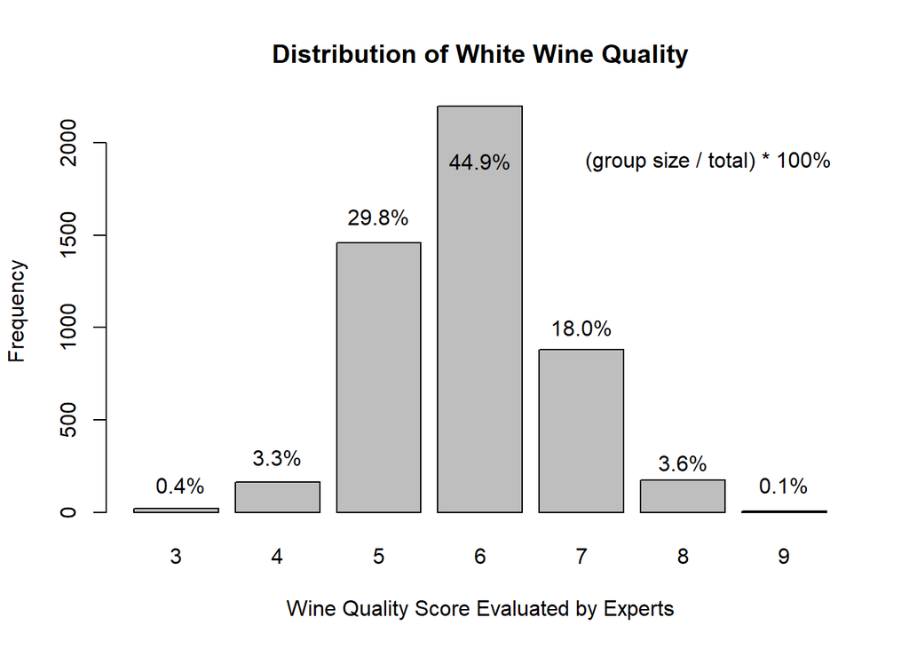

### Description One

Quality was normally distributed. Quality score 6 is the most common quality for white wines (45%). Most white wines had a quality score between 5 and 6, which accounting for 75% of the total. If I predict that a product of white wine is in quality of 5 or 6, there will be 75% chance to be correct. White wines with a quality score between 5 and 7 and that between 4 and 8 were 92.6% and 99.5%, respectively, whereas it is very rare to be quality 3 or 9.

### 3.2 Plot Two

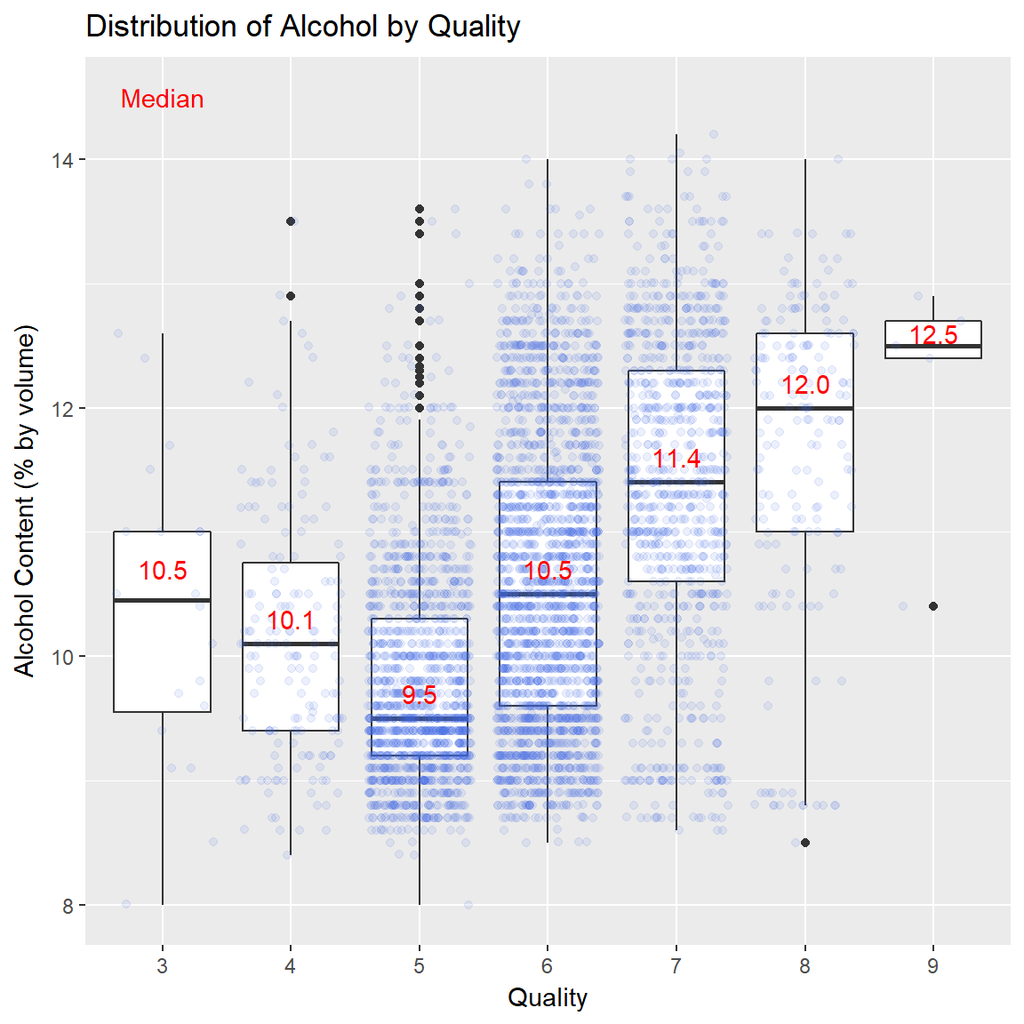

### Description Two

Among physicochemical properties, alcohol has shown to have the strongest linear relationship with quality, especially between 5 and 9. In general, quality increases as alcohol content increases. However, due to such high variability in alcohol within the quality class, alcohol can explain only about 20% of variance in quality with a Pearson’s correlation coefficient of 0.436.

### 3.3 Plot Three

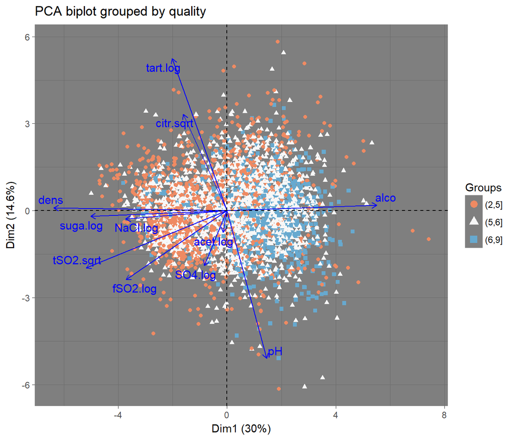

### Description Three

The PCA biplot was constructed by 1st dimension scores on the x-axis and 2nd dimension scores on the y-axis and the points represent individual observations in the dataset, which were color-encoded by quality groups (<6, 6, and >6). The arrows represent correlation of each variables with the two dimension scores: the direction of the arrow represents either positive or negative correlation with both axes, and the length represents the magnitude of correlation coefficient. For example, the arrow of alcohol heads for the positive direction of 1st dimension score with relatively high length. This means that alcohol is strongly and positively correlated with Dim1.

There was a general trend from low to high quality as shifting from left to right, although the separation of groups was not quite clear. One of interesting interactions was that some of physicochemical properties were very dependent on each other. Increase in density of wine was influenced largely by decrease in alcohol and increase in most solutes such as sugar, NaCl, and SO2. In addition, increase in pH (decrease in acidity) was affected by decrease in tartaric acid and citric acid. This plot helped understand the relationship among the physicochemical properties rather than suggest a prediction for sensory quality.

One of my speculations on these trends with wine quality is that too much amount of any solutes might bring unpleasant smell and taste to wine, which was suggested by the arrows of all solute variables were heading to the left where low quality wines more likely present around left-side coordinate. One possible reason could be that high amount of solutes negatively influences the condition for yeast growth. For example, high salt content affects the osmotic pressure in wine, causing cell shrink and slowing down the cell growth and, consequently, the fermentation process. On the other hands, the reverse, where the fermentation process affects the amount of solutes, could happen. The high amount of the solutes could be resulted from too early or too late harvesting time of wine product. If its harvesting is too early, a large amount of sugar remains in the wine, resulting in being too sweet. If it is too late, alcohol is decomposed to acetic acid, resulting in being too sour. Alternatively, the sensory quality evaluation might be influenced by bias of expert tasters, who have a role to guide sort of standards of wine quality to the wine industry and customers. I think this might lead that wine experts value well-balanced flavors rather than exotic and unique flavors of wine for a broader range of customers. As a result, the wine with extreme or unique range of solutes might be rated low.

Overall, I have learned that predicting the quality of wine is very complicated and hard to be accomplished solely based on physicochemical properties given. The limitation of these properties is only examining chemicals in the liquid stage. So, any gas form of chemicals such as aroma can be complementary information to existing dataset.

# 4. Reflection

One of my frustrations as a newbie to R was tuning plots one by one, like adjusting bin size, font, color, label, etc. Although I knew that all the plots did not need to be perfect at the exploring stage, tuning steps to improve aesthetic factors in plots took me a large chunk of time. To figure out how to change the visual factors I had to search examples and documentation of each library, because a lot of libraries do not share same functions and arguments. Despite the frustrations, I think R offers advantages such as flexibility and great accessibility to libraries. Before this project, I have been using python for exploring datasets (e.g. titanic dataset). Compared to the python jupyter notebook, I have felt that the syntax of R is easier and less restricted, and R provides a lot better graphs and more complex statistics with a simple line of code. But I had hard time to make functions or loops to avoid repeating codes. Unlike python, it lacks iterating functionality. I prefer to copy and paste codes rather than writing function, particularly when I try to draw chart. And another drawback, I felt, is that R runs slower than python and RStuio stopped running several times while I was working on this project.

I have tried 3 different types of PCA functions: prcomp, and princomp, and psych.principal. How to get a summary about PCA matrix data was quite similar by using the tree methods, but for plotting PCA, each method can be implemented in a different plotting library. They were not exchangeable sometimes. What I wanted to do for the PCA biplot was to have variable vectors and to color data points by a group. I have tried many different arguments and attributes but I found a library (factoextra) to visualize plots specially for PCA with very minimum lines of codes, instead of extracting PCA scores into dataframe and making plots using ggplot.

I think the next step for this project can be performing machine learning algorithms. As I mentioned previously, decision tree can be one of candidate classifiers or regressions.

# 5. Sources

- [relative frequency by a column](http://www.r-tutor.com/elementary-statistics/qualitative-data/relative-frequency-distribution-qualitative-data)
- [returning multiple objects in function](https://stackoverflow.com/questions/8936099/returning-multiple-objects-in-an-r-function)
- [mvoutlier package: Multivariate Outlier Detection Based on Robust Methods](https://cran.r-project.org/web/packages/mvoutlier/mvoutlier.pdf)
- [renaming columns](http://www.cookbook-r.com/Manipulating_data/Renaming_columns_in_a_data_frame/)
- [correlation matrixes using ggcorr](https://briatte.github.io/ggcorr/)
- [change the decimal rounding of the correlation coefficients on ggcorr](https://www.rdocumentation.org/packages/GGally/versions/1.3.1/topics/ggcorr)
- [three digits after decimal point printed in mtable](https://s3.amazonaws.com/content.udacity-data.com/courses/ud651/diamondsExample_2016-05.html)
- [Standardise variables](http://little-book-of-r-for-multivariate-analysis.readthedocs.io/en/latest/src/multivariateanalysis.html)
- [PCA plot using princomp() and qgraph](http://geog.uoregon.edu/GeogR/topics/pca.html)
- [visualize PCA, factoextra lib coupled with prcomp()](http://www.sthda.com/english/rpkgs/factoextra/reference/fviz_pca.html)
- [prcomp() vs. princomp()](http://www.sthda.com/english/wiki/principal-component-analysis-in-r-prcomp-vs-princomp-r-software-and-data-mining)
- [draw 3d pca](http://planspace.org/2013/02/03/pca-3d-visualization-and-clustering-in-r/)
- [rgl plot3d color points by group](http://r.789695.n4.nabble.com/plot3d-color-points-by-group-td3312955.html)
- [add an image to markdown](https://rpubs.com/RatherBit/90926)
- [add text on barplot](https://stats.stackexchange.com/questions/3879/how-to-put-values-over-bars-in-barplot-in-r)
- [add annotation to ggplot](http://ggplot2.tidyverse.org/reference/annotate.html)